# SOCIAL NETWORK ANALYSIS in R

Mustafa Berk ÇELEBİ

08 01 2021

# Sosyal Ağ Analizi Nedir?

Sosyal Ağ Analizi, ağları görselleştirmek, genel ağ yapısının belirli özelliklerini tanımlamak ve ağ yapılarının ve dinamiklerinin matematiksel ve istatistiksel modellerini oluşturmak için kullanılan bir yöntemdir. Sosyal ağlar, bir veya daha fazla ilişki türü tarafından bağlanan bir dizi düğüm olarak tanımlanır. Düğümler genellikle kişiler veya kuruluşlardır, ancak bu düğümler, prensipte diğer birimlere bağlanabilen herhangi bir birim düğüm olarak incelenebilir. Örneğin sosyal ağ analizi web sitelerini, makaleleri, şehirleri, spor müsabakalarındaki bazı verileri incelemek için kullanılabilmektedir

R ile sosyal ağ analizinde grafik algoritmalarının sorunsuz, anlaşılır bir şekilde uygulanması, milyonlarca köşe-kenar ile büyük grafiklerin sorunsuz ve hızlı işlenmesi için “igpraph” paketi ve bu paketin içindeki graph fonksiyonu kullanılır.

# Giriş Örnekler

```r
library(igraph)
```

Bir ağdaki bağlar yönlü veya yönsüz olabilir. Başlangıç olarak yönsüz ağlarla ilgili örnekler verelim. directed=F komutu, ağların yönsüz olmasını sağlar.

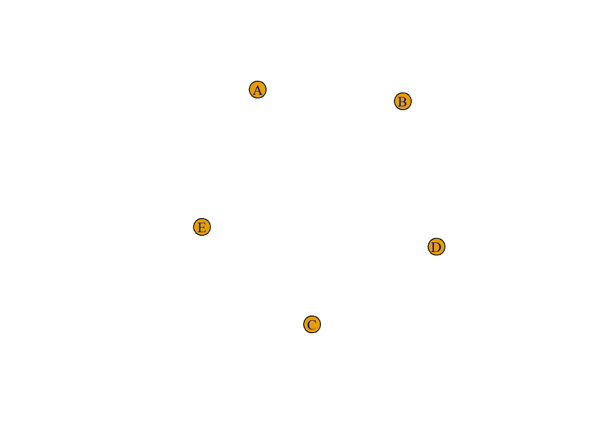

```r
a<-make_empty_graph(directed=F)
a<-a+vertices("A","B","C","D","E")
plot(a)
```

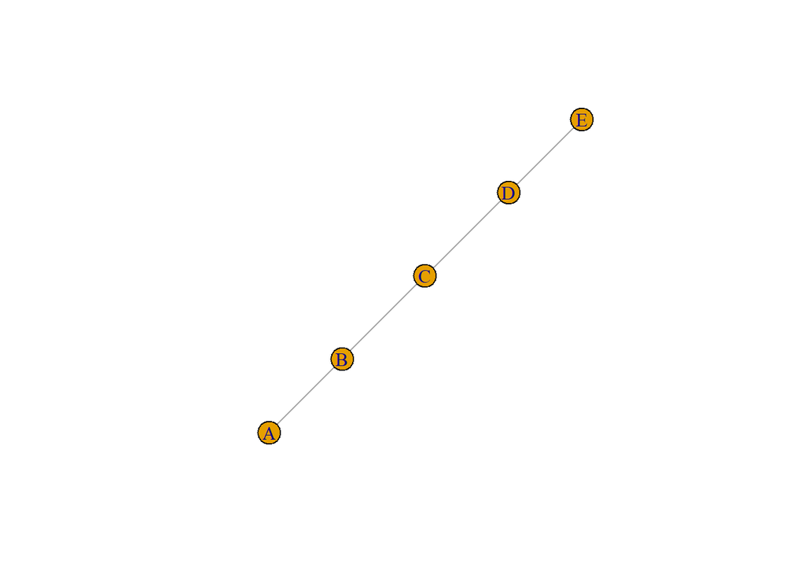

```r
a<-a+edges("A","B","B","C","C","D","D","E")
plot(a)
```

Belirtilen iki düğümün arasında komşuluk olup olmadığı ise aşağıdaki kod ile incelenebilir.

```r
are_adjacent(a,"A","D")
```

```
## [1] FALSE
```

```r
are_adjacent(a,"A","B")
```

```
## [1] TRUE
```

Elimizdeki düğümlerin isimlerini aşağıdaki kodu kullanarak görebiliriz

```r
V(a)
```

```
## + 5/5 vertices, named, from c3d0d89:
## [1] A B C D E
```

Verilen örneklerde şu ana kadar yönsüz ağlar üzerinde durduk. Yönsüz bir ağı, aşağıdaki şekilde yönlü olarak değiştirmemiz mümkündür. Örneğimizde, yönsüz bir ağı tek yönlü bir ağ olarak değiştirelim.

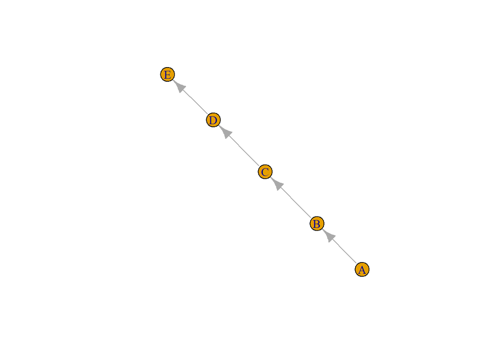

```r
b<-as.directed(a,mode = "arbitrary")
plot(b)
```

Şimdi de yönlü bir ağ örneği olarak, A’dan B’ye giden bir ağ oluşturup ve bunun grafiğini çizdirelim.

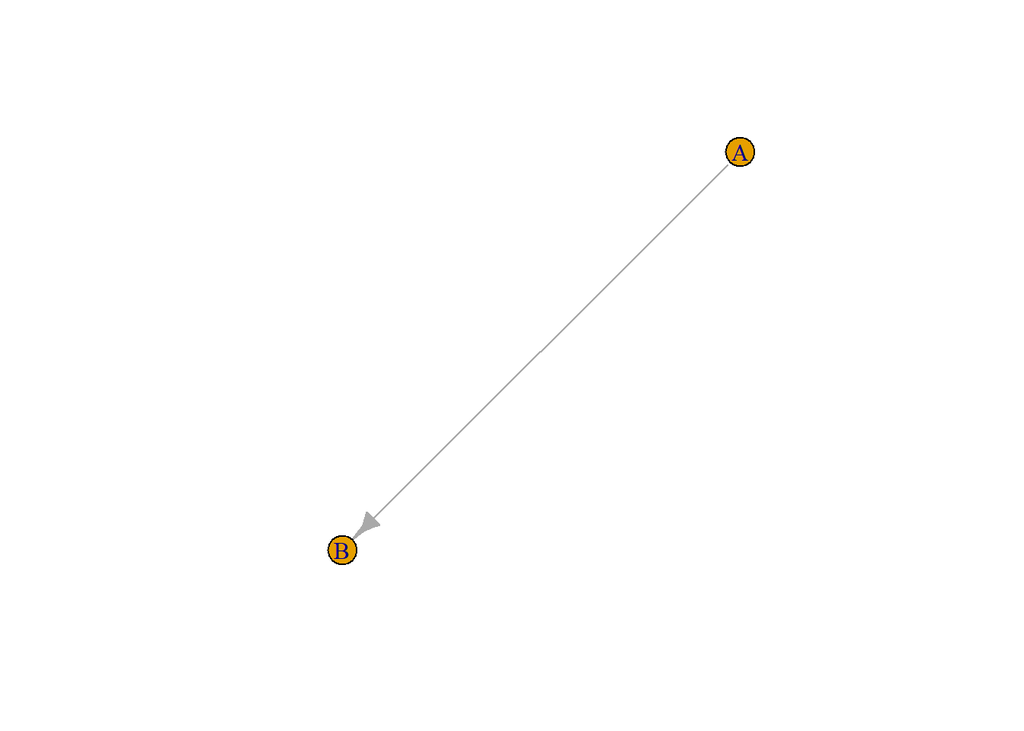

```r
b<-graph(c("A","B"))
plot(b)
```

Grafiklerimizi çizdirirken aynı zamanda düğüm renklerini, boyutlarını değiştirmek gibi birtakım işlemler yapılabilir. İkinci örneğimizde bunu ele alalım.

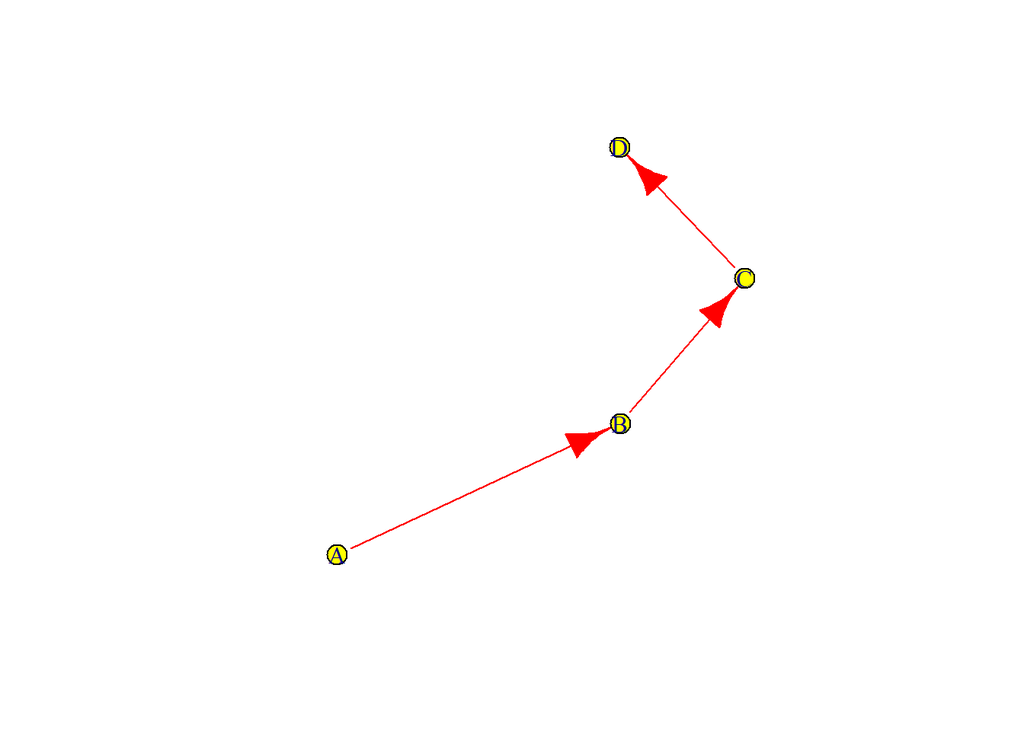

```r
c<-graph(c("A","B","B","C","C","D"))
plot(c, vertex.color="yellow", vertex.size=10, edge.color="red", edge.arrow.size=1.5)
```

Yazdığımız kodun sonucunda, A’dan B’ye, B’den C’ye ve C’den D’ye doğru giden bir ağ ve grafiğini elde ettik. “vertex.color” komutu ile, düğüm renklerini sarı yaptık. “vertex.size” komutu ile, düğümün boyutunu değiştirdik ve 10 yaptık. “edge.color” komutu ile, kenarların boyunu kırmızı olarak değiştirdik. Son olarak “edge.arrow.size” komutu ile de kenarların boyutunun değişmesini sağladık.

Şimdiki örnekte 10 düğümden oluşan bir yıldız ağı oluşturalım.

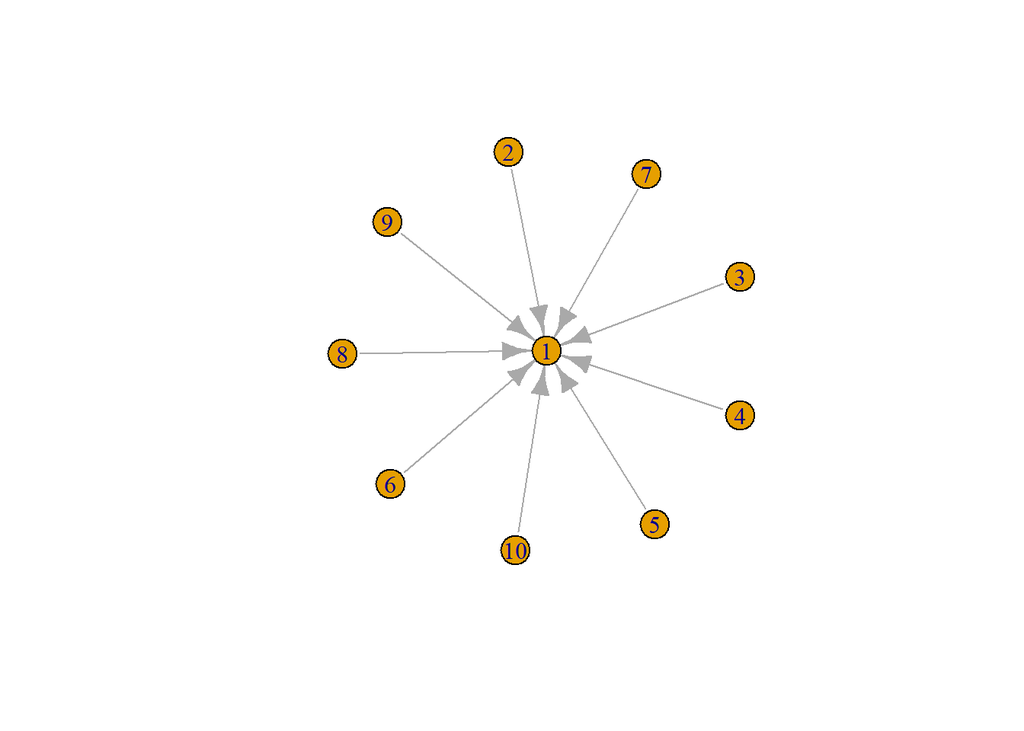

```r
yildiz<-graph.star(10,mode="in")
plot(yildiz)
```

# NBA Oyuncuları Sosyal Ağ Analizi

Öğrendiğimiz bazı komutları bir örnek üzerinde inceleyelim. Sosyal ağ analizi örneği olarak, bir grup NBA oyuncularının verilerini ele alalım. Elimizdeki bilgilerde oyuncuların isimleri, oynadıkları takımlar ve normal sezon MVP ödülünü alıp almadıkları vardır.

```r
library(readxl)
oyuncular_takim <- read_excel("C:/Users/berkc/OneDrive/Masaüstü/oyuncular_takim.xlsx")
oyuncular_mvp <- read_excel("C:/Users/berkc/OneDrive/Masaüstü/oyuncular_mvp.xlsx")

oyuncular_takim
```

```
## # A tibble: 11 x 3
##    Player1          Player2          Teams
##    <chr>            <chr>            <chr>
##  1 Lebron James     JR Smith         Cleveland
##  2 Lebron James     Shawn Marion     Cleveland
##  3 Lebron James     Shaquille O'neal Cleveland
##  4 Dwight Howard    Kobe Bryant      Lakers
##  5 Shaquille O'neal Kobe Bryant      Lakers
##  6 Steve Nash       Kobe Bryant      Lakers
##  7 Pau Gasol        Kobe Bryant      Lakers
##  8 Lebron James     JR Smith         Lakers
##  9 Amare Stoudamire Steve Nash       Suns
## 10 Shaquille O'neal Steve Nash       Suns
## 11 Shawn Marion     Steve Nash       Suns
```

```r
oyuncular_mvp
```

```
## # A tibble: 9 x 2
##   Players          SeasonMVP
##   <chr>            <chr>
## 1 Lebron James     Yes
## 2 JR Smith         No
## 3 Steve Nash       Yes
## 4 Shawn Marion     No
## 5 Shaquille O'neal Yes
## 6 Kobe Bryant      Yes
## 7 Pau Gasol        No
## 8 Dwight Howard    No
## 9 Amare Stoudamire No
```

“oyuncular_takim” adını verdiğimiz data frame’de, Player1 ile Player2 sütunundaki oyuncuların, birlikte hangi takımlarda oynadıkları verilmiştir. “oyuncular_mvp” data frame’inde ise, belirtilen oyuncuların normal sezon MVP’si olup olmadıkları bilgisi verilmiştir.

```r
socialnetwork <- graph_from_data_frame(d=oyuncular_takim, vertices=oyuncular_mvp, directed=F)
```

“degree” fonksiyonu ile, ağımızdaki her bir düğümün kaç adet bağı olduğu konusunda bilgi ediniriz. V() fonksiyonu ile, ağımızdaki düğüm sayısını ve E() fonksiyonu ile de düğümler arası bağları aşağıdaki gibi görebiliriz.

```r
degree(socialnetwork)
```

```
##     Lebron James         JR Smith       Steve Nash     Shawn Marion
##                4                2                4                2
## Shaquille O'neal      Kobe Bryant        Pau Gasol    Dwight Howard
##                3                4                1                1
## Amare Stoudamire
##                1
```

```r
V(socialnetwork)
```

```
## + 9/9 vertices, named, from c57649c:
## [1] Lebron James     JR Smith         Steve Nash       Shawn Marion
## [5] Shaquille O'neal Kobe Bryant      Pau Gasol        Dwight Howard
## [9] Amare Stoudamire
```

```r
E(socialnetwork)
```

```
## + 11/11 edges from c57649c (vertex names):
##  [1] Lebron James    --JR Smith         Lebron James    --Shawn Marion
##  [3] Lebron James    --Shaquille O'neal Kobe Bryant     --Dwight Howard
##  [5] Shaquille O'neal--Kobe Bryant      Steve Nash      --Kobe Bryant
##  [7] Kobe Bryant     --Pau Gasol        Lebron James    --JR Smith
##  [9] Steve Nash      --Amare Stoudamire Steve Nash      --Shaquille O'neal
## [11] Steve Nash      --Shawn Marion
```

graph_from_data_frame() fonksiyonundaki d değişkeni, oluşturduğumuz “oyuncular_takim” dataframe’indeki oyuncuların düğümlerini birbirine bağlayan kenarları alırken, vertices değişkeni ise, “oyuncular_mvp” dataframe’indeki oyuncuların düğümlerini alır. Ağların yönlü ve yönsüz olabileceğini söylemiştik. Bu ağımızda, birlikte farklı takımlarda oynayan oyuncuların olduğunu göz önüne alarak, ağımız yönsüz olacaktır. Şimdi plot fonksiyonu ile ağımızı çizdirelim.

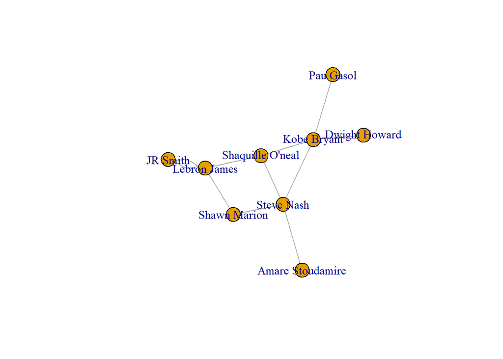

```r
plot(socialnetwork)
```

plot fonksiyonu ile çizdirdiğimiz grafikte, diğer ek bilgilere yer verilmeksizin elimizdeki ağa ait daha basit bir grafikle karşılaşıyoruz. Ek bilgileri de ekleyerek ağımızı çeşitli şekillerde görselleştirebiliriz. Örneğin oyuncular arasındaki bağları, birlikte oynadıkları takımlara göre renklendirelim. Birlikte Lakers takımında oynayan oyuncular arasındaki bağı mor, Cleveland takımında oynayan oyuncuları kırmızı, diğer takımda, yani Suns takımında birlikte oynayan oyuncular arasındaki bağ ise turuncu olsun. Ayrıca bir oyuncu MVP ödülün aldıysa düğümü altın renginde, almadıysa ise siyah renkte olsun.

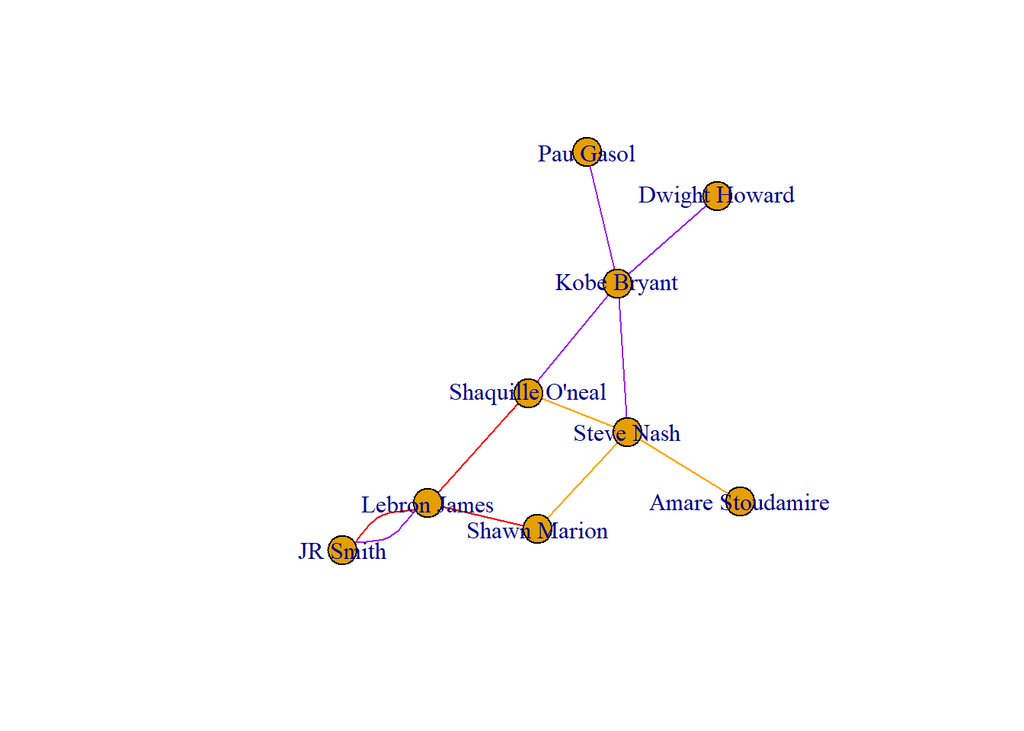

```r
E(socialnetwork)$color <- ifelse(E(socialnetwork)$Teams == "Lakers", "purple",
                    ifelse(E(socialnetwork)$Teams == "Cleveland","red","orange"))
plot(socialnetwork)
```

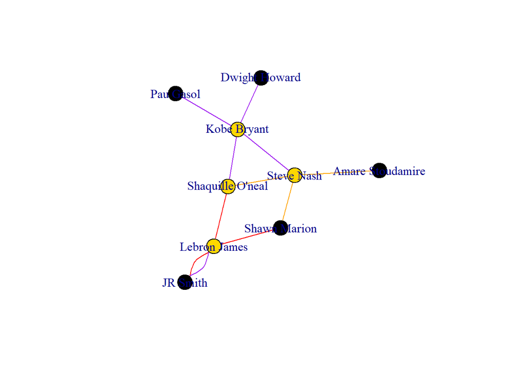

```r
V(socialnetwork)$color <- ifelse(V(socialnetwork)$SeasonMVP == "Yes", "gold","black")

plot(socialnetwork)
```

Belli görselleştirmeleri yaptık. Son olarak da bu görselleri daha anlaşılır bir hale getirelim. Burada “legend” fonksiyonundan yararlanacağız.

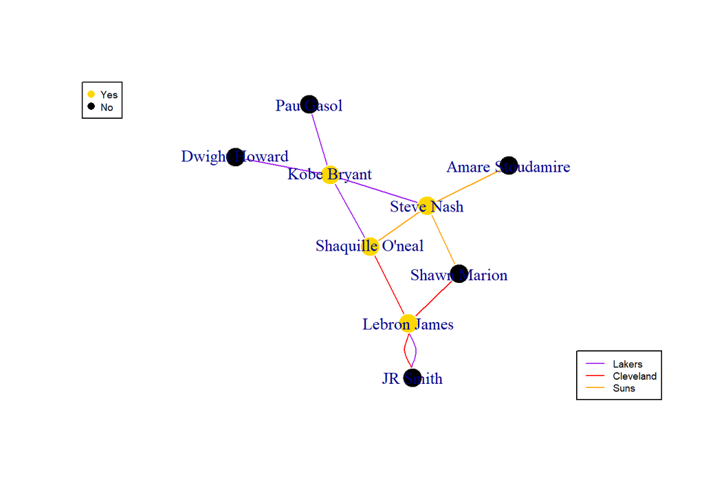

```r
plot(socialnetwork, vertex.frame.color="white")

legend("topleft", c("Yes","No"), pch=16,
       col= c("gold","black"),pt.cex = 1,cex =.6)


legend("bottomright", c("Lakers","Cleveland", "Suns"),
       col=c("purple","red","orange"),lty=1, cex=.6)
```

Görselde gördüğümüz üzere, düğümü siyah renkte olan oyuncuların MVP ödülü kazanamadığını, altın renkte olan oyuncuların ise MVP ödülünü kazandığını görüyoruz. Aralarındaki bağın renginin kırmızı olan oyuncuların, birlikte Cleveland takımında oynadıklarını, mor renkte olan oyuncuların Lakers’ta oynadığını ve aralarındaki bağ renginin turuncu olan oyuncuların ise birlikte Suns takımında oynadıklarını görüyoruz. Örneğin Lebron James’in, Shaquille O’neal ve Shawn Marion ile birlikte Cleveland takımında oynadığını, JR Smith’le ise hem Cleveland, hem Lakers’ta birlikte oynadığını görüyoruz.

# Kaynakça

http://pablobarbera.com/big-data-upf/html/02a-networks-intro-visualization.html http://evelinag.com/blog/2015/12-15-star-wars-social-network/ https://www.geeksforgeeks.org/social-network-analysis-using-r-programming/ https://rpubs.com/wctucker/302110 https://www.webpages.uidaho.edu/~stevel/517/RDM-slides-network-analysis-with-r.pdf espn.com/nba/stats